# Advanced Business Analytics

## 3. Homework: Data Fusion - Data Preparation

**Data preparation** (or data preprocessing) in this context means manipulation of data into a form suitable for further analysis and processing. It is a process that involves many different tasks and which cannot be fully automated. Many of the data preparation activities are routine, tedious, and time consuming. It has been estimated that data preparation accounts for 60%-80% of the time spent on a data mining project!

**Data fusion** is the process of integrating multiple data sources to produce more consistent, accurate, and useful information than that provided by any individual data source.

In this notebook, we are going to work again with the NYC Taxi dataset. We will add a second interesting dataset with weather information, and we will try to produce more useful information for our already formulated prediction models (Week 3 Lecture).

*Note: We will also use a new visualization library called "seaborn". You will need to install the package "seaborn" from anaconda's navigator.*

```python
#Import necessary libraries
import pandas as pd
from pandas import DataFrame, read_csv

import matplotlib
import matplotlib.pyplot as plt
# Enable inline plotting
%matplotlib inline
# matplotlib style options
plt.style.use('ggplot')
plt.rcParams['figure.figsize'] = (15, 8)

import datetime

import numpy as np
from collections import defaultdict

# Python visualization library
import seaborn as sns

import calendar

import numpy
from numpy import nan
```

During the previous lecture we formulated and used a function that reads the necessary csv files at a proper format. We will use it again here:

```python
def my_read_csv(file):
    df = pd.read_csv(file, sep=',', parse_dates={'dt': [0, 1, 2]})
    df['datetime']=df['dt'].apply(lambda x: datetime.datetime.strptime(x, "%Y-%m-%d %H %M"))
    del df['dt']
    return df.set_index('datetime')
```

```python
# Remember to change the path below based on where you have chosen to save your files
s1=my_read_csv("data/pickups_zone_1_15min.csv")
s17=my_read_csv("data/pickups_zone_17_15min.csv")
s21=my_read_csv("data/pickups_zone_21_15min.csv")
s28=my_read_csv("data/pickups_zone_28_15min.csv")

smerge=s1.join(s17, rsuffix="17")
smerge=smerge.join(s21, rsuffix="21")
smerge=smerge.join(s28, rsuffix="28")
smerge['pickups1']=smerge['pickups']
del smerge['pickups']
smerge.head()
```

| datetime | pickups17 | pickups21 | pickups28 | pickups1 |
| --- | --- | --- | --- | --- |
| 2009-01-01 00:00:00 | 339 | 175 | 21 | 0 |
| 2009-01-01 00:15:00 | 285 | 394 | 29 | 166 |
| 2009-01-01 00:30:00 | 214 | 297 | 10 | 215 |
| 2009-01-01 00:45:00 | 202 | 322 | 9 | 223 |
| 2009-01-01 01:00:00 | 198 | 344 | 4 | 245 |

In class's notebook, we successfully found some interesting correlations for example, between area 1 at time t, with area 17 at time t-1. We will use them again here:

```python
# Solution from Stackoverflow as used before
def buildLaggedFeatures(s,columns, lag=1, dropna=True):
    '''
    From http://stackoverflow.com/questions/20410312/how-to-create-a-lagged-data-structure-using-pandas-dataframe
    Builds a new DataFrame to facilitate regressing over all possible lagged features
    '''
    if type(s) is pd.DataFrame:
        new_dict={}
        for c in s.columns:
            new_dict[c]=s[c]
        for col_name in columns:
            new_dict[col_name]=s[col_name]
            # create lagged Series
            for l in range(1,lag+1):
                new_dict['%s_lag%d' %(col_name,l)]=s[col_name].shift(l)
        res=pd.DataFrame(new_dict,index=s.index)

    elif type(s) is pd.Series:
        the_range=range(lag+1)
        res=pd.concat([s.shift(i) for i in the_range],axis=1)
        res.columns=['lag_%d' %i for i in the_range]
    else:
        print('Only works for DataFrame or Series')
        return None
    if dropna:
        return res.dropna()
    else:
        return res
```

```python
smerged_lagged_s1=buildLaggedFeatures(smerge, ['pickups1', 'pickups17', 'pickups21', 'pickups28'])
```

```python
smerged_lagged_s1.head()
```

| datetime | pickups1 | pickups17 | pickups17_lag1 | pickups1_lag1 | pickups21 | pickups21_lag1 | pickups28 | pickups28_lag1 |
| --- | --- | --- | --- | --- | --- | --- | --- | --- |
| 2009-01-01 00:15:00 | 166 | 285 | 339.0 | 0.0 | 394 | 175.0 | 29 | 21.0 |
| 2009-01-01 00:30:00 | 215 | 214 | 285.0 | 166.0 | 297 | 394.0 | 10 | 29.0 |
| 2009-01-01 00:45:00 | 223 | 202 | 214.0 | 215.0 | 322 | 297.0 | 9 | 10.0 |
| 2009-01-01 01:00:00 | 245 | 198 | 202.0 | 223.0 | 344 | 322.0 | 4 | 9.0 |
| 2009-01-01 01:15:00 | 182 | 196 | 198.0 | 245.0 | 352 | 344.0 | 17 | 4.0 |

## Weather Data

This public dataset was created by the National Oceanic and Atmospheric Administration (NOAA) and includes global data obtained from the USAF Climatology Center. This dataset covers GSOD data between 1929 and 2016, collected from over 9000 stations.

https://cloud.google.com/bigquery/public-data/noaa-gsod

```python
dfWeather=pd.read_csv("data/gsod2016.csv")
```

```python
dfWeather.head()
```

|  | stn | wban | year | mo | da | temp | count_temp | dewp | count_dewp | slp | ... | flag_min | prcp | flag_prcp | sndp | fog | rain_drizzle | snow_ice_pellets | hail | thunder | tornado_funnel_cloud |
| --- | --- | --- | --- | --- | --- | --- | --- | --- | --- | --- | --- | --- | --- | --- | --- | --- | --- | --- | --- | --- | --- |
| 0 | 10010 | 99999 | 2016 | 10 | 22 | 44.0 | 24 | 9999.9 | 0 | 1018.0 | ... | NaN | 0.57 | G | 999.9 | 0 | 1 | 0 | 0 | 0 | 0 |
| 1 | 10060 | 99999 | 2016 | 7 | 16 | 42.0 | 24 | 9999.9 | 0 | 1008.4 | ... | NaN | 0.00 | I | 999.9 | 0 | 0 | 0 | 0 | 0 | 0 |
| 2 | 10090 | 99999 | 2016 | 6 | 9 | 31.7 | 17 | 9999.9 | 0 | 1009.5 | ... | * | 0.00 | I | 999.9 | 0 | 0 | 0 | 0 | 0 | 0 |
| 3 | 10090 | 99999 | 2016 | 12 | 31 | 17.8 | 11 | 9999.9 | 0 | 1014.1 | ... | NaN | 0.00 | I | 999.9 | 0 | 0 | 0 | 0 | 0 | 0 |
| 4 | 10090 | 99999 | 2016 | 1 | 20 | 26.3 | 24 | 9999.9 | 0 | 1006.3 | ... | NaN | 0.00 | I | 999.9 | 0 | 0 | 0 | 0 | 0 | 0 |

5 rows × 32 columns

```python
list(dfWeather)
```

```
['stn',
 'wban',
 'year',
 'mo',
 'da',
 'temp',
 'count_temp',
 'dewp',
 'count_dewp',
 'slp',
 'count_slp',
 'stp',
 'count_stp',
 'visib',
 'count_visib',
 'wdsp',
 'count_wdsp',
 'mxpsd',
 'gust',
 'max',
 'flag_max',
 'min',
 'flag_min',
 'prcp',
 'flag_prcp',
 'sndp',
 'fog',
 'rain_drizzle',
 'snow_ice_pellets',
 'hail',
 'thunder',
 'tornado_funnel_cloud']
```

The dataset includes weather data from the whole world. We should find a way to select only the weather data referring to Manhattan.

As you can see from the list of attributes above, there is a key that could help us select what we need; the **stn** key, that represents the station ID from which each record has been collected.

But since an ID number does not allow us to know to which area it refers to, we will use a second dataset with the list of all stations and their location details.

```python
stations=pd.read_csv("data/stations.csv")
```

```python
len(stations)
```

```
31700
```

```python
stations.tail()
```

|  | usaf | wban | name | country | fips | state | call | lat | lon | elev | begin | end |
| --- | --- | --- | --- | --- | --- | --- | --- | --- | --- | --- | --- | --- |
| 31695 | 719675 | 99999 | BEAVER CREEK ARPT | CN | CA | YT | CYXQ | 62417.0 | -140867.0 | 6490.0 | 19430820.0 | 20120618.0 |
| 31696 | 719680 | 99999 | SHINGLE POINT | CN | CA | YT | CYUA | 68950.0 | -137217.0 | 380.0 | 19770701.0 | 20120618.0 |
| 31697 | 719770 | 99999 | MARGARET LAKE | CN | CA | YT | WZR | 68800.0 | -140850.0 | 5680.0 | 19950423.0 | 20120618.0 |
| 31698 | 719780 | 99999 | IVVAVIK PARK AUTO8 | CN | CA | YT | CWOI | 69150.0 | -140150.0 | 2440.0 | 19950901.0 | 20120618.0 |
| 31699 | 719900 | 99999 | MACMILLAN PASS | CN | CA | YT | CWNV | 63250.0 | -130032.0 | 13790.0 | 20030617.0 | 20120618.0 |

```python
stations.head()
```

|  | usaf | wban | name | country | fips | state | call | lat | lon | elev | begin | end |
| --- | --- | --- | --- | --- | --- | --- | --- | --- | --- | --- | --- | --- |
| 0 | 7005 | 99999 | CWOS 07005 | NaN | NaN | NaN | NaN | -99999.0 | -999999.0 | -99999.0 | 20120127.0 | 20120127.0 |
| 1 | 7011 | 99999 | CWOS 07011 | NaN | NaN | NaN | NaN | -99999.0 | -999999.0 | -99999.0 | 20111025.0 | 20120314.0 |
| 2 | 7018 | 99999 | WXPOD 7018 | NaN | NaN | NaN | 7018 | 0.0 | 0.0 | 70180.0 | 20110309.0 | 20110705.0 |
| 3 | 7025 | 99999 | CWOS 07025 | NaN | NaN | NaN | NaN | -99999.0 | -999999.0 | -99999.0 | 20120127.0 | 20120127.0 |
| 4 | 7037 | 99999 | CWOS 07037 | NaN | NaN | NaN | NaN | -99999.0 | -999999.0 | -99999.0 | 20111202.0 | 20111202.0 |

```python
stations.describe()
```

|  | usaf | wban | lat | lon | elev | begin | end |
| --- | --- | --- | --- | --- | --- | --- | --- |
| count | 31700.000000 | 31700.000000 | 30049.000000 | 30048.000000 | 29730.000000 | 2.830800e+04 | 2.830800e+04 |
| mean | 582886.002366 | 91675.120284 | 28342.274785 | -19817.141174 | 1458.393676 | 1.975730e+07 | 2.000283e+07 |
| std | 307261.203586 | 24802.198189 | 32979.612623 | 155805.387587 | 15697.799181 | 2.335553e+05 | 1.794752e+05 |
| min | 6852.000000 | 1.000000 | -99999.000000 | -999999.000000 | -99999.000000 | 1.892010e+07 | 1.905123e+07 |
| 25% | 336555.000000 | 99999.000000 | 19967.000000 | -86057.500000 | 170.000000 | 1.957010e+07 | 1.997031e+07 |
| 50% | 702607.000000 | 99999.000000 | 38217.000000 | 4517.000000 | 1260.000000 | 1.974061e+07 | 2.009061e+07 |
| 75% | 786392.500000 | 99999.000000 | 48767.000000 | 64914.750000 | 4210.000000 | 1.998041e+07 | 2.012062e+07 |
| max | 999999.000000 | 99999.000000 | 89383.000000 | 179750.000000 | 83180.000000 | 2.012061e+07 | 2.012062e+07 |

We cannot see cleary which stations refer to Manhattan, therefore we will filter the dataset using the lat-lon columns.

### Manhattan Isolation using lat-lon

```python
# Selection of values based on openstreetmap website export tools
# http://www.openstreetmap.org/export#map=11/40.7504/-73.9359

minlong = -74.04
minlat = 40.69
maxlong = -73.91
maxlat = 40.82
```

```python
masklong = (stations['lon'] >= minlong) & (stations['lon'] <= maxlong)
stationsLon = (stations.loc[masklong])

masklat = (stationsLon['lat'] >= minlat) & (stationsLon['lat'] <= maxlat)
stationsLonLat = (stationsLon.loc[masklat])
```

Now that we filtered the dataset, let's see how many stations we have...

```python
len(stationsLonLat)
```

```
0
```

Well... Something goes wrong here... Let's see how many stations are actually located on Earth!!

```python
minlong1 = -180
minlat1 = -90
maxlong1 = 180
maxlat1 = 90
```

```python
masklong = (stations['lon'] >= minlong1) & (stations['lon'] <= maxlong1)
stationsLon1 = (stations.loc[masklong])

masklat = (stationsLon1['lat'] >= minlat1) &(stationsLon1['lat'] <= maxlat1)
stationsLonLat1 = (stationsLon1.loc[masklat])
```

```python
len(stationsLonLat1)
```

```
18
```

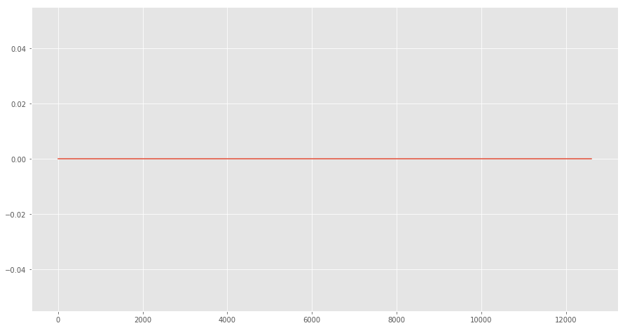

```python
plt.plot(stationsLonLat1.lon)
```

Only 18 stations have reasonable lat-lon values... Therefore, we cannot do much using those attributes. Let's see if we can use the column **state**.

```python
stations.loc[stations['state']=='NY'].head()
```

|  | usaf | wban | name | country | fips | state | call | lat | lon | elev | begin | end |
| --- | --- | --- | --- | --- | --- | --- | --- | --- | --- | --- | --- | --- |
| 29025 | 692504 | 99999 | AFWA ASSIGNED | US | US | NY | KQWS | -99999.0 | -999999.0 | -99999.0 | 19780105.0 | 20100513.0 |
| 29026 | 724098 | 99999 | AMBROSE/FT TILDEN | US | US | NY | KN28 | 40450.0 | -73817.0 | 10.0 | 19750915.0 | 19870430.0 |
| 29027 | 724988 | 99999 | DANSVILLE MUNI | US | US | NY | KDSV | 42571.0 | -77713.0 | 2020.0 | 20010811.0 | 20031231.0 |
| 29028 | 725010 | 99999 | UPTON | US | US | NY | NaN | 40850.0 | -72850.0 | 260.0 | 19990503.0 | 20050927.0 |
| 29029 | 725026 | 99999 | BRONX/EXECUTION CGS | US | US | NY | KN84 | 40883.0 | -73733.0 | 80.0 | 19750915.0 | 19791127.0 |

As you can see, there are stations in NY. Can you see which is the problem and why we could not see them before?

It seems that the information of decimals from the lat-lon columns has been lost. We can restore it by making the following division:

```python
stations.loc[:,'lat'] /= 1000
stations.loc[:,'lon'] /= 1000
```

```python
stations.loc[stations['state']=='NY'].head()
```

|  | usaf | wban | name | country | fips | state | call | lat | lon | elev | begin | end |
| --- | --- | --- | --- | --- | --- | --- | --- | --- | --- | --- | --- | --- |
| 29025 | 692504 | 99999 | AFWA ASSIGNED | US | US | NY | KQWS | -99.999 | -999.999 | -99999.0 | 19780105.0 | 20100513.0 |
| 29026 | 724098 | 99999 | AMBROSE/FT TILDEN | US | US | NY | KN28 | 40.450 | -73.817 | 10.0 | 19750915.0 | 19870430.0 |
| 29027 | 724988 | 99999 | DANSVILLE MUNI | US | US | NY | KDSV | 42.571 | -77.713 | 2020.0 | 20010811.0 | 20031231.0 |
| 29028 | 725010 | 99999 | UPTON | US | US | NY | NaN | 40.850 | -72.850 | 260.0 | 19990503.0 | 20050927.0 |
| 29029 | 725026 | 99999 | BRONX/EXECUTION CGS | US | US | NY | KN84 | 40.883 | -73.733 | 80.0 | 19750915.0 | 19791127.0 |

So now let's use again our lat-lon filter...

```python
masklong = (stations['lon'] >= minlong) & (stations['lon'] <= maxlong)
stationsLon = (stations.loc[masklong])

masklat = (stationsLon['lat'] >= minlat) &(stationsLon['lat'] <= maxlat)
stationsLonLat = (stationsLon.loc[masklat])
```

```python
stationsLonLat
```

|  | usaf | wban | name | country | fips | state | call | lat | lon | elev | begin | end |
| --- | --- | --- | --- | --- | --- | --- | --- | --- | --- | --- | --- | --- |
| 29031 | 725033 | 94728 | NYC CENTRAL PARK | US | US | NY | KNYC | 40.779 | -73.969 | 475.0 | 19431201.0 | 20100731.0 |
| 29092 | 999999 | 94706 | NEW YORK WB CITY | US | US | NY | NaN | 40.700 | -74.017 | 3.0 | 18930101.0 | 19400101.0 |
| 29093 | 999999 | 94728 | NEW YORK CENTRAL PARK ARSNL B | US | US | NY | KNYC | 40.779 | -73.969 | 475.0 | 19650101.0 | 19991231.0 |
| 29105 | 720552 | 99999 | NYC WEST 30TH HELIPO | US | US | NY | KJRA | 40.750 | -74.000 | 20.0 | NaN | NaN |
| 29106 | 720553 | 99999 | PORT AUTH DOWNTN MAN | US | US | NY | KJRB | 40.701 | -74.009 | 20.0 | NaN | NaN |
| 29140 | 725060 | 99999 | NYC CENTRAL PARK | US | US | NY | KNYC | 40.767 | -73.967 | 490.0 | 19490101.0 | 20051231.0 |
| 29156 | 997271 | 99999 | THE BATTERY | US | US | NY | BATN6 | 40.700 | -74.000 | 100.0 | 20050104.0 | 20120618.0 |
| 29178 | 725060 | 94728 | NYC CENTRAL PARK | US | US | NY | KNYC | 40.779 | -73.969 | 475.0 | 20100801.0 | 20120619.0 |

Therefore, in total we have 8 weather stations in the area of Manhattan. By examining again the header of the weather database, we can see that there is a common key between them and the stations dataset; the **"wban"**. So our next goal is to isolate the weather data for the stations that we are interested in.

```python
stationsLonLat.wban.unique()
```

```
array([94728, 94706, 99999])
```

```python
wbanNY = stationsLonLat.wban.unique()[:2]
print(wbanNY)
```

```
[94728 94706]
```

```python
weatherNY = dfWeather.loc[dfWeather['wban'].isin(wbanNY)]
```

```python
weatherNY.describe()
```

|  | stn | wban | year | mo | da | temp | count_temp | dewp | count_dewp | slp | ... | max | min | prcp | sndp | fog | rain_drizzle | snow_ice_pellets | hail | thunder | tornado_funnel_cloud |
| --- | --- | --- | --- | --- | --- | --- | --- | --- | --- | --- | --- | --- | --- | --- | --- | --- | --- | --- | --- | --- | --- |
| count | 366.0 | 366.0 | 366.0 | 366.000000 | 366.000000 | 366.000000 | 366.000000 | 366.000000 | 366.000000 | 366.000000 | ... | 366.000000 | 366.000000 | 366.000000 | 366.000000 | 366.000000 | 366.000000 | 366.000000 | 366.0 | 366.0 | 366.0 |
| mean | 725053.0 | 94728.0 | 2016.0 | 6.513661 | 15.756831 | 56.861202 | 23.874317 | 41.227322 | 23.871585 | 1237.692350 | ... | 66.871858 | 48.698361 | 0.120328 | 964.659836 | 0.065574 | 0.297814 | 0.054645 | 0.0 | 0.0 | 0.0 |
| std | 0.0 | 0.0 | 0.0 | 3.455958 | 8.823592 | 16.885540 | 1.196134 | 18.851690 | 1.196988 | 1393.157141 | ... | 17.526078 | 16.594297 | 0.293690 | 183.890014 | 0.247874 | 0.457923 | 0.227597 | 0.0 | 0.0 | 0.0 |
| min | 725053.0 | 94728.0 | 2016.0 | 1.000000 | 1.000000 | 6.900000 | 5.000000 | -16.100000 | 5.000000 | 992.100000 | ... | 21.900000 | -0.900000 | 0.000000 | 1.200000 | 0.000000 | 0.000000 | 0.000000 | 0.0 | 0.0 | 0.0 |
| 25% | 725053.0 | 94728.0 | 2016.0 | 4.000000 | 8.000000 | 43.600000 | 24.000000 | 26.725000 | 24.000000 | 1012.400000 | ... | 53.700000 | 36.000000 | 0.000000 | 999.900000 | 0.000000 | 0.000000 | 0.000000 | 0.0 | 0.0 | 0.0 |
| 50% | 725053.0 | 94728.0 | 2016.0 | 7.000000 | 16.000000 | 55.950000 | 24.000000 | 41.100000 | 24.000000 | 1017.050000 | ... | 66.100000 | 46.900000 | 0.000000 | 999.900000 | 0.000000 | 0.000000 | 0.000000 | 0.0 | 0.0 | 0.0 |
| 75% | 725053.0 | 94728.0 | 2016.0 | 9.750000 | 23.000000 | 72.800000 | 24.000000 | 57.550000 | 24.000000 | 1021.900000 | ... | 82.900000 | 64.000000 | 0.060000 | 999.900000 | 0.000000 | 1.000000 | 0.000000 | 0.0 | 0.0 | 0.0 |
| max | 725053.0 | 94728.0 | 2016.0 | 12.000000 | 31.000000 | 87.800000 | 24.000000 | 74.800000 | 24.000000 | 9999.900000 | ... | 96.100000 | 79.000000 | 2.200000 | 999.900000 | 1.000000 | 1.000000 | 1.000000 | 0.0 | 0.0 | 0.0 |

8 rows × 29 columns

So now let's keep in a new dataframe only the attributes that we believe could be useful...

```python
weatherNY = weatherNY[['wban','year','mo','da','temp','prcp','sndp','fog','rain_drizzle']]
weatherNY.describe()
```

|  | wban | year | mo | da | temp | prcp | sndp | fog | rain_drizzle |
| --- | --- | --- | --- | --- | --- | --- | --- | --- | --- |
| count | 366.0 | 366.0 | 366.000000 | 366.000000 | 366.000000 | 366.000000 | 366.000000 | 366.000000 | 366.000000 |
| mean | 94728.0 | 2016.0 | 6.513661 | 15.756831 | 56.861202 | 0.120328 | 964.659836 | 0.065574 | 0.297814 |
| std | 0.0 | 0.0 | 3.455958 | 8.823592 | 16.885540 | 0.293690 | 183.890014 | 0.247874 | 0.457923 |
| min | 94728.0 | 2016.0 | 1.000000 | 1.000000 | 6.900000 | 0.000000 | 1.200000 | 0.000000 | 0.000000 |
| 25% | 94728.0 | 2016.0 | 4.000000 | 8.000000 | 43.600000 | 0.000000 | 999.900000 | 0.000000 | 0.000000 |
| 50% | 94728.0 | 2016.0 | 7.000000 | 16.000000 | 55.950000 | 0.000000 | 999.900000 | 0.000000 | 0.000000 |
| 75% | 94728.0 | 2016.0 | 9.750000 | 23.000000 | 72.800000 | 0.060000 | 999.900000 | 0.000000 | 1.000000 |
| max | 94728.0 | 2016.0 | 12.000000 | 31.000000 | 87.800000 | 2.200000 | 999.900000 | 1.000000 | 1.000000 |

Everything looks normal, except sndp (check quantiles). Since the value "999.9" does not give any information, we will replace it with "NaN" (In computing, NaN, standing for *not a number*, is a numeric data type value representing an undefined or unrepresentable value.).

```python
weatherNY.loc[weatherNY.sndp == 999.9, 'sndp'] = nan
weatherNY.describe()
```

|  | wban | year | mo | da | temp | prcp | sndp | fog | rain_drizzle |
| --- | --- | --- | --- | --- | --- | --- | --- | --- | --- |
| count | 366.0 | 366.0 | 366.000000 | 366.000000 | 366.000000 | 366.000000 | 13.000000 | 366.000000 | 366.000000 |
| mean | 94728.0 | 2016.0 | 6.513661 | 15.756831 | 56.861202 | 0.120328 | 7.753846 | 0.065574 | 0.297814 |
| std | 0.0 | 0.0 | 3.455958 | 8.823592 | 16.885540 | 0.293690 | 7.031905 | 0.247874 | 0.457923 |
| min | 94728.0 | 2016.0 | 1.000000 | 1.000000 | 6.900000 | 0.000000 | 1.200000 | 0.000000 | 0.000000 |
| 25% | 94728.0 | 2016.0 | 4.000000 | 8.000000 | 43.600000 | 0.000000 | 2.000000 | 0.000000 | 0.000000 |
| 50% | 94728.0 | 2016.0 | 7.000000 | 16.000000 | 55.950000 | 0.000000 | 5.900000 | 0.000000 | 0.000000 |
| 75% | 94728.0 | 2016.0 | 9.750000 | 23.000000 | 72.800000 | 0.060000 | 9.100000 | 0.000000 | 1.000000 |
| max | 94728.0 | 2016.0 | 12.000000 | 31.000000 | 87.800000 | 2.200000 | 22.000000 | 1.000000 | 1.000000 |

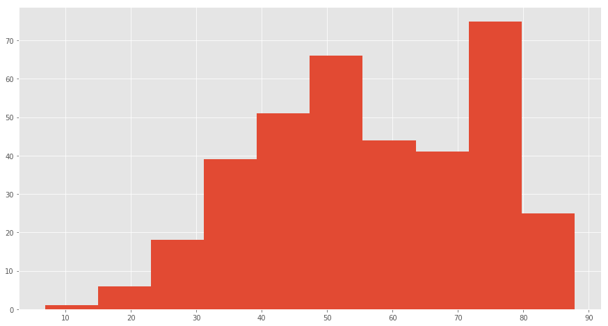

```python
weatherNY.temp.hist()
```

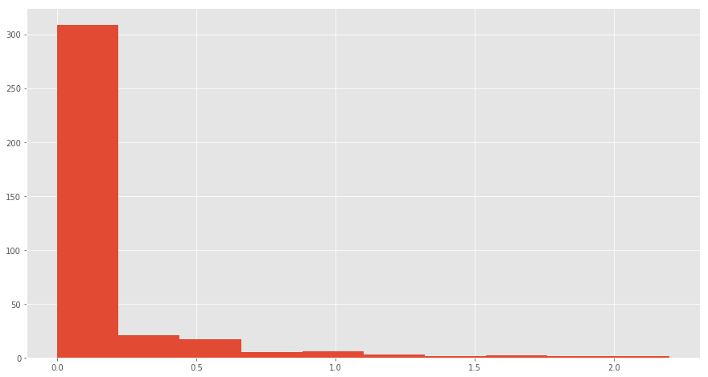

```python
weatherNY.prcp.hist()
```

From the histograms above, we can verify that our dataset has a normal range of temperature and precipitation values.

So now let's create some new plots using the seaborn library!

First, I would like to add a new column in my current dataframe with the name of the month. The column **"mo"** has already the number of the month, so I will use the **"calendar.month_abbr"** for the correspondence of each number in the name of the month.

```python
monthList = []

for i in range(len(weatherNY)):
    monthList.append(calendar.month_abbr[weatherNY.mo[weatherNY.index[i]]])

weatherNY["month"] = monthList
```

```python
weatherNY
```

|  | wban | year | mo | da | temp | prcp | sndp | fog | rain_drizzle | month |
| --- | --- | --- | --- | --- | --- | --- | --- | --- | --- | --- |
| 57885 | 94728 | 2016 | 12 | 9 | 36.0 | 0.00 | NaN | 0 | 0 | Dec |
| 1033943 | 94728 | 2016 | 12 | 8 | 42.2 | 0.09 | NaN | 0 | 0 | Dec |
| 1505421 | 94728 | 2016 | 5 | 13 | 61.0 | 0.00 | NaN | 0 | 0 | May |
| 1900718 | 94728 | 2016 | 5 | 15 | 54.6 | 0.00 | NaN | 0 | 0 | May |
| 1928255 | 94728 | 2016 | 1 | 8 | 40.2 | 0.00 | NaN | 0 | 0 | Jan |
| 2288287 | 94728 | 2016 | 12 | 5 | 42.8 | 0.17 | NaN | 0 | 1 | Dec |
| 2288288 | 94728 | 2016 | 1 | 24 | 26.7 | 1.82 | 5.9 | 1 | 0 | Jan |
| 2288289 | 94728 | 2016 | 11 | 19 | 55.2 | 0.00 | NaN | 0 | 0 | Nov |
| 2288290 | 94728 | 2016 | 5 | 31 | 76.0 | 0.00 | NaN | 0 | 0 | May |
| 2288291 | 94728 | 2016 | 8 | 19 | 80.0 | 0.00 | NaN | 0 | 0 | Aug |
| 2288292 | 94728 | 2016 | 3 | 8 | 55.1 | 0.00 | NaN | 0 | 0 | Mar |
| 2288293 | 94728 | 2016 | 7 | 22 | 82.8 | 0.00 | NaN | 0 | 0 | Jul |
| 2288294 | 94728 | 2016 | 9 | 12 | 69.5 | 0.00 | NaN | 0 | 0 | Sep |
| 2288295 | 94728 | 2016 | 6 | 15 | 73.2 | 0.00 | NaN | 0 | 0 | Jun |
| 2288296 | 94728 | 2016 | 6 | 23 | 75.2 | 0.00 | NaN | 0 | 0 | Jun |
| 2288297 | 94728 | 2016 | 1 | 29 | 38.3 | 0.00 | 5.9 | 0 | 0 | Jan |
| 2288298 | 94728 | 2016 | 8 | 21 | 78.0 | 0.82 | NaN | 1 | 1 | Aug |
| 2288299 | 94728 | 2016 | 3 | 29 | 48.5 | 0.24 | NaN | 0 | 0 | Mar |
| 2288300 | 94728 | 2016 | 12 | 19 | 28.4 | 0.02 | 1.2 | 0 | 0 | Dec |
| 2288301 | 94728 | 2016 | 8 | 18 | 78.8 | 0.03 | NaN | 0 | 1 | Aug |
| 2288302 | 94728 | 2016 | 8 | 20 | 76.7 | 0.01 | NaN | 1 | 1 | Aug |
| 2288303 | 94728 | 2016 | 3 | 15 | 48.0 | 0.27 | NaN | 0 | 1 | Mar |
| 2288304 | 94728 | 2016 | 11 | 8 | 52.0 | 0.00 | NaN | 0 | 0 | Nov |
| 2288305 | 94728 | 2016 | 9 | 28 | 64.4 | 0.00 | NaN | 0 | 0 | Sep |
| 2288306 | 94728 | 2016 | 4 | 25 | 58.0 | 0.00 | NaN | 0 | 0 | Apr |
| 2288307 | 94728 | 2016 | 8 | 3 | 71.5 | 0.00 | NaN | 0 | 0 | Aug |
| 2288308 | 94728 | 2016 | 10 | 28 | 47.8 | 1.41 | NaN | 0 | 1 | Oct |
| 2288309 | 94728 | 2016 | 4 | 3 | 41.0 | 0.25 | NaN | 0 | 1 | Apr |
| 2288310 | 94728 | 2016 | 2 | 4 | 54.7 | 0.73 | NaN | 0 | 0 | Feb |
| 2288311 | 94728 | 2016 | 7 | 6 | 83.3 | 0.66 | NaN | 0 | 0 | Jul |
| ... | ... | ... | ... | ... | ... | ... | ... | ... | ... | ... |
| 4141428 | 94728 | 2016 | 9 | 21 | 75.3 | 0.00 | NaN | 0 | 0 | Sep |
| 4141429 | 94728 | 2016 | 5 | 7 | 52.2 | 0.30 | NaN | 0 | 0 | May |
| 4141430 | 94728 | 2016 | 11 | 1 | 48.9 | 0.00 | NaN | 0 | 0 | Nov |
| 4141431 | 94728 | 2016 | 6 | 16 | 70.6 | 0.20 | NaN | 0 | 1 | Jun |
| 4141432 | 94728 | 2016 | 4 | 8 | 47.3 | 0.09 | NaN | 0 | 0 | Apr |
| 4141433 | 94728 | 2016 | 11 | 28 | 44.3 | 0.00 | NaN | 0 | 0 | Nov |
| 4141434 | 94728 | 2016 | 10 | 22 | 53.4 | 1.32 | NaN | 0 | 1 | Oct |
| 4141435 | 94728 | 2016 | 8 | 15 | 82.6 | 0.06 | NaN | 0 | 0 | Aug |
| 4141436 | 94728 | 2016 | 3 | 20 | 37.8 | 0.00 | NaN | 0 | 0 | Mar |
| 4141437 | 94728 | 2016 | 12 | 1 | 51.4 | 0.80 | NaN | 0 | 1 | Dec |
| 4141438 | 94728 | 2016 | 8 | 23 | 71.2 | 0.00 | NaN | 0 | 0 | Aug |
| 4141439 | 94728 | 2016 | 2 | 6 | 34.6 | 0.15 | 1.2 | 0 | 0 | Feb |
| 4141440 | 94728 | 2016 | 8 | 7 | 79.0 | 0.05 | NaN | 0 | 0 | Aug |
| 4141441 | 94728 | 2016 | 11 | 29 | 54.2 | 0.00 | NaN | 1 | 1 | Nov |
| 4141442 | 94728 | 2016 | 2 | 25 | 52.6 | 1.11 | NaN | 0 | 1 | Feb |
| 4141443 | 94728 | 2016 | 1 | 20 | 30.7 | 0.00 | NaN | 0 | 0 | Jan |
| 4141444 | 94728 | 2016 | 1 | 16 | 46.0 | 0.21 | NaN | 0 | 1 | Jan |
| 4141445 | 94728 | 2016 | 4 | 27 | 51.3 | 0.07 | NaN | 0 | 0 | Apr |
| 4141446 | 94728 | 2016 | 10 | 10 | 54.3 | 0.34 | NaN | 0 | 0 | Oct |
| 4141447 | 94728 | 2016 | 1 | 2 | 35.8 | 0.00 | NaN | 0 | 0 | Jan |
| 4141448 | 94728 | 2016 | 1 | 30 | 32.8 | 0.00 | 5.9 | 0 | 0 | Jan |
| 4141449 | 94728 | 2016 | 11 | 27 | 43.5 | 0.00 | NaN | 0 | 0 | Nov |
| 4141450 | 94728 | 2016 | 10 | 13 | 60.1 | 0.00 | NaN | 0 | 0 | Oct |
| 4141451 | 94728 | 2016 | 1 | 28 | 37.0 | 0.00 | 9.1 | 0 | 0 | Jan |
| 4141452 | 94728 | 2016 | 3 | 14 | 46.3 | 0.02 | NaN | 0 | 1 | Mar |
| 4141453 | 94728 | 2016 | 8 | 26 | 82.4 | 0.01 | NaN | 0 | 0 | Aug |
| 4141454 | 94728 | 2016 | 8 | 11 | 84.3 | 0.08 | NaN | 0 | 1 | Aug |
| 4141455 | 94728 | 2016 | 4 | 29 | 51.4 | 0.00 | NaN | 0 | 1 | Apr |
| 4141456 | 94728 | 2016 | 9 | 27 | 68.1 | 0.22 | NaN | 0 | 1 | Sep |
| 4141457 | 94728 | 2016 | 9 | 19 | 72.7 | 0.24 | NaN | 0 | 1 | Sep |

366 rows × 10 columns

```python
def show_weather_stats(dataset, variable, ticks):
    # Initialize a grid of plots with an Axes for each walk
    grid = sns.FacetGrid(dataset,col="month", hue="month", col_wrap=4, size=3)

    # Draw a line plot to show the trajectory of each random walk
    grid.map(plt.plot, "da", variable, marker="o")

    # Adjust the tick positions and labels
    grid.set(yticks=ticks)

    # Adjust the arrangement of the plots
    grid.fig.tight_layout(w_pad=1)
    plt.show()
```

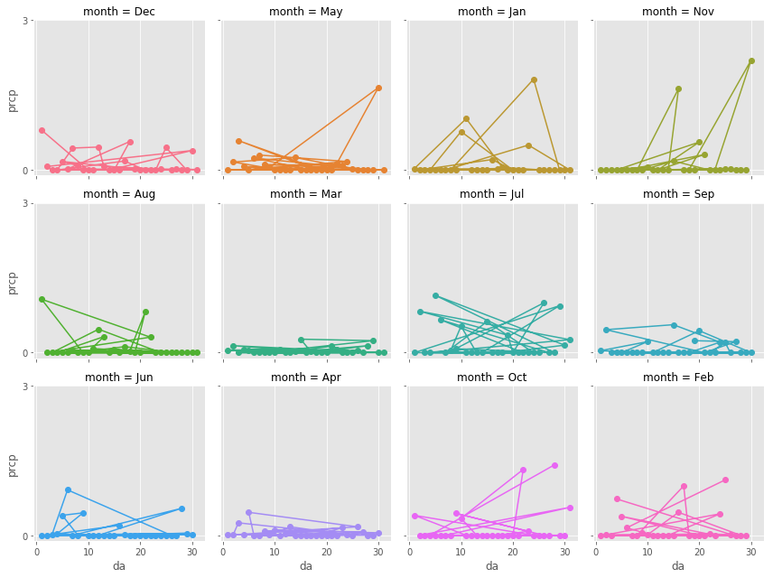

```python
# Choose to plot the precipitation values within the range [0,3]
show_weather_stats(weatherNY, "prcp", [0,3])
```

Each plot has lines that unites randomly the various points. This usually happens when our dataset is not sorted chronologically. Our next goal is to modify records' order based on the date they refer to.

```python
dateList = []

for i in range(len(weatherNY)):
    date1 = datetime.date(year=weatherNY.year[weatherNY.index[i]],day=weatherNY.da[weatherNY.index[i]],month=weatherNY.mo[weatherNY.index[i]])
    #date2 = datetime.datetime.combine(date1,datetime.time())
    dateList.append(date1)
```

```python
# Add a new column with the date
weatherNY["date"] = dateList
```

```python
# Sort values based on the date
weatherNYSorted = weatherNY.sort_values(by='date')
weatherNYSorted.head()
```

|  | wban | year | mo | da | temp | prcp | sndp | fog | rain_drizzle | month | date |
| --- | --- | --- | --- | --- | --- | --- | --- | --- | --- | --- | --- |
| 3588849 | 94728 | 2016 | 1 | 1 | 40.4 | 0.03 | NaN | 0 | 0 | Jan | 2016-01-01 |
| 4141447 | 94728 | 2016 | 1 | 2 | 35.8 | 0.00 | NaN | 0 | 0 | Jan | 2016-01-02 |
| 4141403 | 94728 | 2016 | 1 | 3 | 38.4 | 0.00 | NaN | 0 | 0 | Jan | 2016-01-03 |
| 4141406 | 94728 | 2016 | 1 | 4 | 30.8 | 0.00 | NaN | 0 | 0 | Jan | 2016-01-04 |
| 2288323 | 94728 | 2016 | 1 | 5 | 18.4 | 0.00 | NaN | 0 | 0 | Jan | 2016-01-05 |

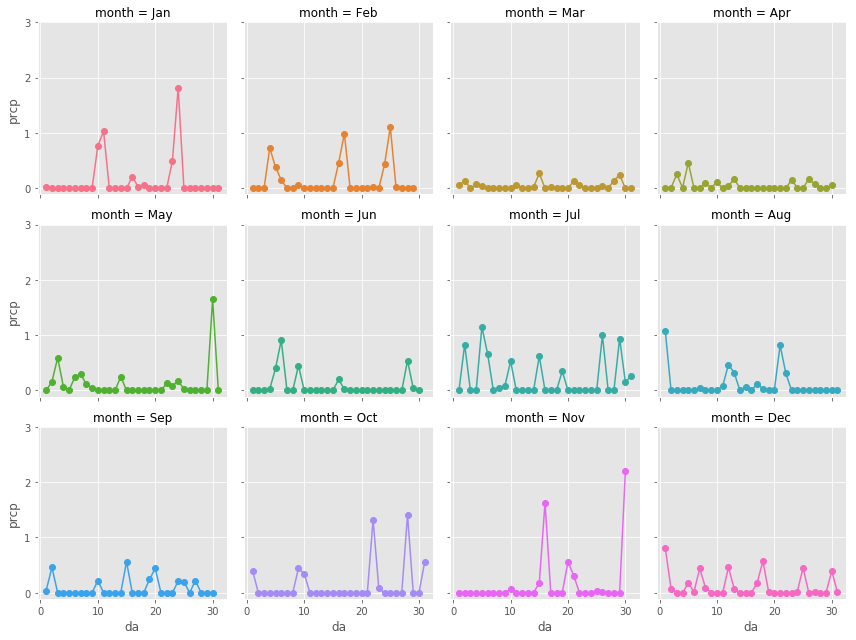

```python
# Redo the plot
show_weather_stats(weatherNYSorted, "prcp", [0,1,2,3])
```

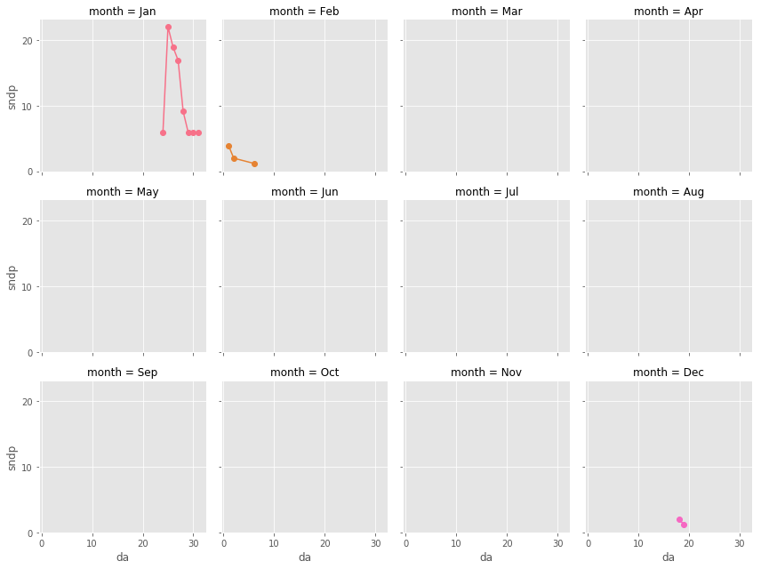

```python
# Make a plot for the snow
show_weather_stats(weatherNYSorted, "sndp", [0, 10, 20])
```

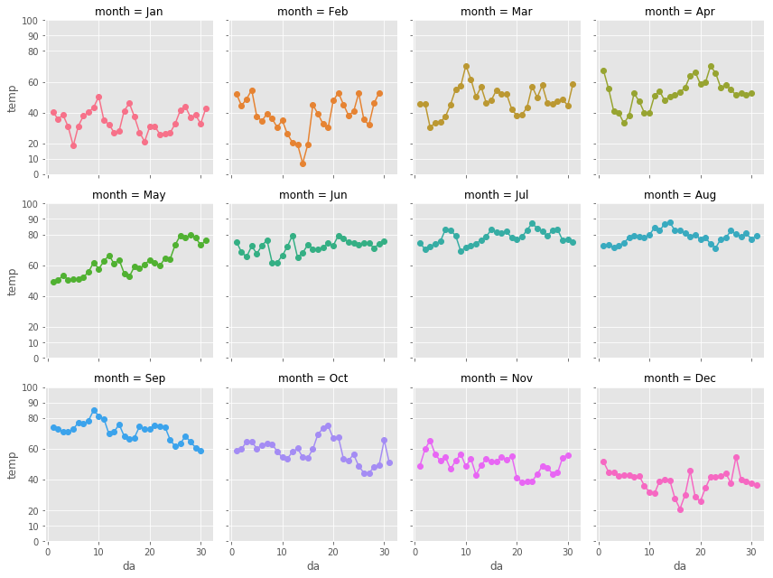

```python
# Finally, make a plot for the temperature values
show_weather_stats(weatherNYSorted, "temp", [0, 10, 20, 40, 60, 80, 90, 100])
```

### Add weather information to our initial dataset

```python
# Create a new column "date" in the initial dataset (with lags)
smerged_lagged_s1['date']=[d.date() for d in smerged_lagged_s1.index]
```

```python
smerged_lagged_s1.head()
```

| datetime | pickups1 | pickups17 | pickups17_lag1 | pickups1_lag1 | pickups21 | pickups21_lag1 | pickups28 | pickups28_lag1 | date |
| --- | --- | --- | --- | --- | --- | --- | --- | --- | --- |
| 2009-01-01 00:15:00 | 166 | 285 | 339.0 | 0.0 | 394 | 175.0 | 29 | 21.0 | 2009-01-01 |
| 2009-01-01 00:30:00 | 215 | 214 | 285.0 | 166.0 | 297 | 394.0 | 10 | 29.0 | 2009-01-01 |
| 2009-01-01 00:45:00 | 223 | 202 | 214.0 | 215.0 | 322 | 297.0 | 9 | 10.0 | 2009-01-01 |
| 2009-01-01 01:00:00 | 245 | 198 | 202.0 | 223.0 | 344 | 322.0 | 4 | 9.0 | 2009-01-01 |
| 2009-01-01 01:15:00 | 182 | 196 | 198.0 | 245.0 | 352 | 344.0 | 17 | 4.0 | 2009-01-01 |

```python
# Remove index (but keep the datetime information) so that the merging process will be more clear later.
smerged_lagged_s1=smerged_lagged_s1.reset_index()
smerged_lagged_s1.head()
```

|  | datetime | pickups1 | pickups17 | pickups17_lag1 | pickups1_lag1 | pickups21 | pickups21_lag1 | pickups28 | pickups28_lag1 | date |
| --- | --- | --- | --- | --- | --- | --- | --- | --- | --- | --- |
| 0 | 2009-01-01 00:15:00 | 166 | 285 | 339.0 | 0.0 | 394 | 175.0 | 29 | 21.0 | 2009-01-01 |
| 1 | 2009-01-01 00:30:00 | 215 | 214 | 285.0 | 166.0 | 297 | 394.0 | 10 | 29.0 | 2009-01-01 |
| 2 | 2009-01-01 00:45:00 | 223 | 202 | 214.0 | 215.0 | 322 | 297.0 | 9 | 10.0 | 2009-01-01 |
| 3 | 2009-01-01 01:00:00 | 245 | 198 | 202.0 | 223.0 | 344 | 322.0 | 4 | 9.0 | 2009-01-01 |
| 4 | 2009-01-01 01:15:00 | 182 | 196 | 198.0 | 245.0 | 352 | 344.0 | 17 | 4.0 | 2009-01-01 |

```python
# Merge two datasets using the "date" as the key
result=pd.merge(smerged_lagged_s1, weatherNYSorted, on='date', how='inner') # how: inner -> use intersection of keys from both frames, similar to a SQL inner join
```

```python
# Set again the datetime as index
result=result.set_index('datetime')
```

```python
# Save the final result
result.to_csv('NYC_taxi_weather.csv')
```

As you can see, weather information has been included in our dataset (for 2016 only)

### Isolation of 2016 Taxi Data

```python
TaxiData2016 = result.iloc[result.index.year == 2016]
TaxiData2016.head()
```

| datetime | pickups1 | pickups17 | pickups17_lag1 | pickups1_lag1 | pickups21 | pickups21_lag1 | pickups28 | pickups28_lag1 | date | wban | year | mo | da | temp | prcp | sndp | fog | rain_drizzle | month |
| --- | --- | --- | --- | --- | --- | --- | --- | --- | --- | --- | --- | --- | --- | --- | --- | --- | --- | --- | --- |
| 2016-01-01 00:00:00 | 162 | 394 | 202.0 | 109.0 | 312 | 198.0 | 29 | 40.0 | 2016-01-01 | 94728 | 2016 | 1 | 1 | 40.4 | 0.03 | NaN | 0 | 0 | Jan |
| 2016-01-01 00:15:00 | 251 | 420 | 394.0 | 162.0 | 699 | 312.0 | 16 | 29.0 | 2016-01-01 | 94728 | 2016 | 1 | 1 | 40.4 | 0.03 | NaN | 0 | 0 | Jan |
| 2016-01-01 00:30:00 | 310 | 310 | 420.0 | 251.0 | 482 | 699.0 | 3 | 16.0 | 2016-01-01 | 94728 | 2016 | 1 | 1 | 40.4 | 0.03 | NaN | 0 | 0 | Jan |
| 2016-01-01 00:45:00 | 338 | 403 | 310.0 | 310.0 | 459 | 482.0 | 2 | 3.0 | 2016-01-01 | 94728 | 2016 | 1 | 1 | 40.4 | 0.03 | NaN | 0 | 0 | Jan |
| 2016-01-01 01:00:00 | 369 | 398 | 403.0 | 338.0 | 495 | 459.0 | 0 | 2.0 | 2016-01-01 | 94728 | 2016 | 1 | 1 | 40.4 | 0.03 | NaN | 0 | 0 | Jan |

```python
TaxiData2016.corr()
```

|  | pickups1 | pickups17 | pickups17_lag1 | pickups1_lag1 | pickups21 | pickups21_lag1 | pickups28 | pickups28_lag1 | wban | year | mo | da | temp | prcp | sndp | fog | rain_drizzle |
| --- | --- | --- | --- | --- | --- | --- | --- | --- | --- | --- | --- | --- | --- | --- | --- | --- | --- |
| pickups1 | 1.000000 | 0.879679 | 0.851783 | 0.973192 | 0.891969 | 0.899918 | 0.658863 | 0.644222 | NaN | NaN | 0.078300 | -0.018438 | 0.051813 | -0.090062 | -0.041170 | -0.117067 | 0.002453 |
| pickups17 | 0.879679 | 1.000000 | 0.979705 | 0.894312 | 0.778260 | 0.808654 | 0.672338 | 0.678541 | NaN | NaN | -0.012950 | -0.024026 | -0.039924 | -0.066639 | -0.102610 | -0.078589 | 0.016216 |
| pickups17_lag1 | 0.851783 | 0.979705 | 1.000000 | 0.879685 | 0.739500 | 0.778300 | 0.662738 | 0.672350 | NaN | NaN | -0.012904 | -0.023696 | -0.040203 | -0.066735 | -0.103594 | -0.076642 | 0.016097 |
| pickups1_lag1 | 0.973192 | 0.894312 | 0.879685 | 1.000000 | 0.870708 | 0.891993 | 0.668620 | 0.658874 | NaN | NaN | 0.078282 | -0.018200 | 0.051566 | -0.090061 | -0.042418 | -0.115575 | 0.002432 |
| pickups21 | 0.891969 | 0.778260 | 0.739500 | 0.870708 | 1.000000 | 0.970589 | 0.667156 | 0.642274 | NaN | NaN | 0.040306 | -0.044210 | 0.008280 | -0.070272 | -0.112052 | -0.079411 | 0.012940 |
| pickups21_lag1 | 0.899918 | 0.808654 | 0.778300 | 0.891993 | 0.970589 | 1.000000 | 0.687217 | 0.667181 | NaN | NaN | 0.040264 | -0.043990 | 0.008155 | -0.070040 | -0.112042 | -0.078558 | 0.012866 |
| pickups28 | 0.658863 | 0.672338 | 0.662738 | 0.668620 | 0.667156 | 0.687217 | 1.000000 | 0.915072 | NaN | NaN | 0.073330 | -0.014736 | 0.064607 | -0.009540 | 0.142353 | -0.051306 | 0.001580 |
| pickups28_lag1 | 0.644222 | 0.678541 | 0.672350 | 0.658874 | 0.642274 | 0.667181 | 0.915072 | 1.000000 | NaN | NaN | 0.073480 | -0.014528 | 0.064746 | -0.010702 | 0.139735 | -0.052977 | 0.000872 |
| wban | NaN | NaN | NaN | NaN | NaN | NaN | NaN | NaN | NaN | NaN | NaN | NaN | NaN | NaN | NaN | NaN | NaN |
| year | NaN | NaN | NaN | NaN | NaN | NaN | NaN | NaN | NaN | NaN | NaN | NaN | NaN | NaN | NaN | NaN | NaN |
| mo | 0.078300 | -0.012950 | -0.012904 | 0.078282 | 0.040306 | 0.040264 | 0.073330 | 0.073480 | NaN | NaN | 1.000000 | -0.000550 | 0.822230 | -0.064293 | -0.588860 | -0.096395 | 0.100842 |
| da | -0.018438 | -0.024026 | -0.023696 | -0.018200 | -0.044210 | -0.043990 | -0.014736 | -0.014528 | NaN | NaN | -0.000550 | 1.000000 | 0.182537 | 0.017450 | 0.492428 | -0.000238 | -0.069905 |
| temp | 0.051813 | -0.039924 | -0.040203 | 0.051566 | 0.008280 | 0.008155 | 0.064607 | 0.064746 | NaN | NaN | 0.822230 | 0.182537 | 1.000000 | -0.032580 | -0.085058 | -0.125891 | 0.133266 |
| prcp | -0.090062 | -0.066639 | -0.066735 | -0.090061 | -0.070272 | -0.070040 | -0.009540 | -0.010702 | NaN | NaN | -0.064293 | 0.017450 | -0.032580 | 1.000000 | -0.171194 | 0.447396 | 0.189749 |
| sndp | -0.041170 | -0.102610 | -0.103594 | -0.042418 | -0.112052 | -0.112042 | 0.142353 | 0.139735 | NaN | NaN | -0.588860 | 0.492428 | -0.085058 | -0.171194 | 1.000000 | -0.138942 | 0.106412 |
| fog | -0.117067 | -0.078589 | -0.076642 | -0.115575 | -0.079411 | -0.078558 | -0.051306 | -0.052977 | NaN | NaN | -0.096395 | -0.000238 | -0.125891 | 0.447396 | -0.138942 | 1.000000 | 0.143497 |
| rain_drizzle | 0.002453 | 0.016216 | 0.016097 | 0.002432 | 0.012940 | 0.012866 | 0.001580 | 0.000872 | NaN | NaN | 0.100842 | -0.069905 | 0.133266 | 0.189749 | 0.106412 | 0.143497 | 1.000000 |